# FTDR Assignment 1: Logistic Regression

## Outlier handling

```r
data_pre_outlier_rmvl <- data_parsed

numeric_columns <- c("construction_year",
                     "service_fee",
                     "minimum_nights",
                     "number_of_reviews",
                     "reviews_per_month",
                     "review_rate_number",
                     "availability_365",
                     "price_usd")
```

### General

#### Visualization summarization function

```r
plot_info <- function(data, column_name) {
  # Ensure the input column exists in the dataset
  if (!column_name %in% names(data)) {
    stop(paste("Column", column_name, "not found in the dataset."))
  }

  # Extract the column
  column_data <- data[[column_name]]

  # Ensure the column is numeric
  if (!is.numeric(column_data)) {
    stop(paste("Column", column_name, "is not numeric."))
  }

  # Histogram
  hist_plot <- ggplot(data, aes(x = !!sym(column_name))) +
    geom_histogram(bins = 30, fill = "skyblue", color = "black") +
    labs(title = paste("Histogram of", column_name), x = column_name, y = "Frequency") +
    theme_minimal()

  # Boxplot
  box_plot <- ggplot(data, aes(x = !!sym(column_name))) +
    geom_boxplot(fill = "skyblue", color = "black") +
    labs(title = paste("Boxplot of", column_name), x = column_name, y = "") +
    theme_minimal()

  # Density Plot
  density_plot <- ggplot(data, aes(x = !!sym(column_name))) +
    geom_density(fill = "skyblue", alpha = 0.5) +
    labs(title = paste("Density Plot of", column_name), x = column_name, y = "Density") +
    theme_minimal()

  # Q-Q Plot
  qq_plot <- ggplot(data, aes(sample = !!sym(column_name))) +
    stat_qq(color = "skyblue") +
    stat_qq_line(color = "red") +
    labs(title = paste("Q-Q Plot of", column_name), x = "Theoretical Quantiles", y = "Sample Quantiles") +
    theme_minimal()

  # Combine all plots into a 2x2 grid
  combined_plot <- (hist_plot | density_plot) / (box_plot | qq_plot)

  # Print the combined plot
  print(combined_plot)
}
```

#### Negative numeric removal

```r
# Count total rows
nrow_bef_negremoval <- nrow(data_pre_outlier_rmvl)

# Remove all rows that contain values lower than 0
data_outlier_0 <- data_pre_outlier_rmvl %>%
  dplyr::filter(
    service_fee >= 0,
    minimum_nights >= 0,
    number_of_reviews >= 0,
    reviews_per_month >= 0,
    review_rate_number >= 0,
    availability_365 >= 0,
    price_usd >= 0
  )

# Print n removed rows
cat(nrow_bef_negremoval - nrow(data_outlier_0), "rows removed")
```

```
## 346 rows removed
```

#### IQR

```r
detect_outliers_iqr <- function(data, columns) {
  for (col in columns) {
    # Calculate Q1, Q3, and IQR
    Q1 <- quantile(data[[col]], 0.25, na.rm = TRUE)
    Q3 <- quantile(data[[col]], 0.75, na.rm = TRUE)
    IQR <- Q3 - Q1

    # Calculate lower and upper bounds
    lower_bound <- Q1 - 1.5 * IQR
    upper_bound <- Q3 + 1.5 * IQR

    # Print bounds for the variable
    cat("---", col, "---\n")
    cat("Q1:", Q1, "Q3:", Q3, "IQR:", IQR, "\n")
    cat("Lower Bound:", lower_bound, "Upper Bound:", upper_bound, "\n")

    # Count outliers
    num_outliers <- sum(data[[col]] < lower_bound | data[[col]] > upper_bound, na.rm = TRUE)
    cat("Number of outliers:", num_outliers, "\n\n")

    # Filter out outliers
    data <- data[data[[col]] >= lower_bound & data[[col]] <= upper_bound, ]
  }
  return(data)
}
```

```r
# Apply IQR outlier removal
data_iqr <- detect_outliers_iqr(data_outlier_0, numeric_columns)
```

```
## --- construction_year ---
## Q1: 2007 Q3: 2017 IQR: 10
## Lower Bound: 1992 Upper Bound: 2032
## Number of outliers: 0
##
## --- service_fee ---
## Q1: 68 Q3: 183 IQR: 115
## Lower Bound: -104.5 Upper Bound: 355.5
## Number of outliers: 0
##
## --- minimum_nights ---
## Q1: 2 Q3: 5 IQR: 3
## Lower Bound: -2.5 Upper Bound: 9.5
## Number of outliers: 13904
##
## --- number_of_reviews ---
## Q1: 4 Q3: 43 IQR: 39
## Lower Bound: -54.5 Upper Bound: 101.5
## Number of outliers: 6527
##
## --- reviews_per_month ---
## Q1: 0.23 Q3: 1.93 IQR: 1.7
## Lower Bound: -2.32 Upper Bound: 4.48
## Number of outliers: 2733
##
## --- review_rate_number ---
## Q1: 2 Q3: 4 IQR: 2
## Lower Bound: -1 Upper Bound: 7
## Number of outliers: 0
##
## --- availability_365 ---
## Q1: 0 Q3: 249 IQR: 249
## Lower Bound: -373.5 Upper Bound: 622.5
## Number of outliers: 0
##
## --- price_usd ---
## Q1: 341 Q3: 913 IQR: 572
## Lower Bound: -517 Upper Bound: 1771
## Number of outliers: 0
```

### Specific

#### 1: construction_year

Ziet er prima uit: Geen extreme waarden / outliers.

```r
# Print summary
summary(data_outlier_0$construction_year)
```

```
##    Min. 1st Qu.  Median    Mean 3rd Qu.    Max.
##    2003    2007    2012    2012    2017    2022
```

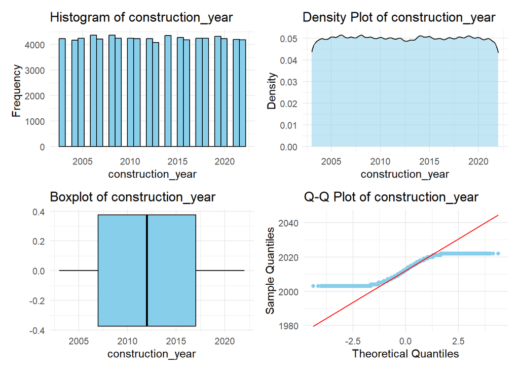

```r
# Plot summary info
plot_info(data_outlier_0, "construction_year")
```

```r
data_outlier_1 <- data_outlier_0
```

#### 2: (service_fee)

Ziet er prima uit: Geen extreme waarden / outliers.

```r
# Print summary
summary(data_outlier_1$service_fee)
```

```
##    Min. 1st Qu.  Median    Mean 3rd Qu.    Max.
##    10.0    68.0   125.0   125.2   183.0   240.0
```

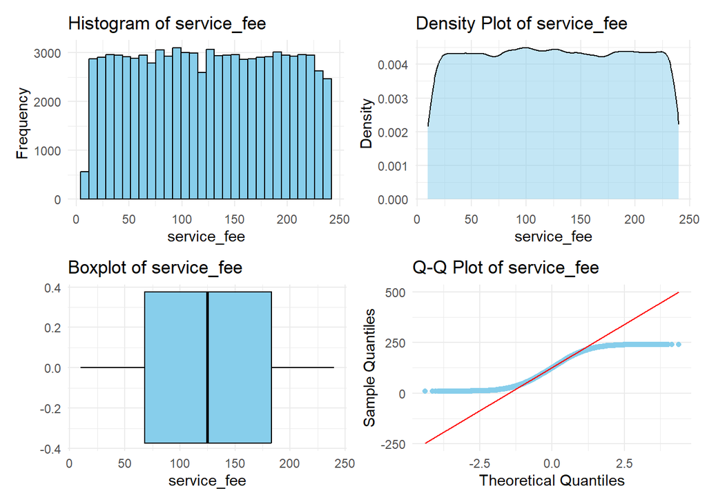

```r
# Plot summary info
plot_info(data_outlier_1, "service_fee")
```

```r
data_outlier_2 <- data_outlier_1
```

#### 3: minimum_nights

Veel extreme waarden: Komt waarschijnlijk omdat de hoge waarden ingesteld worden, zodat mensen niet gaan boeken (Zie bronnen). Geen idee hoe hier mee om te gaan…

1. Boven 90 dagen alles weghalen (maar hier haal je ook legitieme values mee weg)
2. Boven 365 dagen alles weghalen (maar hiermee weinig verschil)

[Reddit 1](https://www.reddit.com/r/AirBnB/comments/1bg4oic/extremely_long_minimum_stay_policies_upwards_of/)

> “I think it might be there way of blocking those dates while still being available on Airbnb search, I’m not sure. I’ve also seen the other method where listings that are usually $50 a night be priced at $10,000 a night. I, too, would like a clear explanation.”

[Reddit 2](https://www.reddit.com/r/AirBnB/comments/tcmlnw/90_day_minimum_stay_on_airbnb/)

> “I often bump up my minimum night stay to actually prevent bookings during a certain time frame. Then one day, to my absolute shock, someone actually booked. So maybe just send them a message, it could be way too many different things.”

> “That’s local government limit. Some government requires the listing to host short term stays only with a permit. If the host didn’t get the permit in time, the listing is enforced to long term stays only. The threshold is per the regulation, generally 30, 90, or even 365 days. Besides, France government also permits a special kind of short term rental, mobility lease, which is 30 days minimum without the permit.”

```r
# Print summary
summary(data_outlier_2$minimum_nights)
```

```
##     Min.  1st Qu.   Median     Mean  3rd Qu.     Max.
##    1.000    2.000    3.000    7.442    5.000 5645.000
```

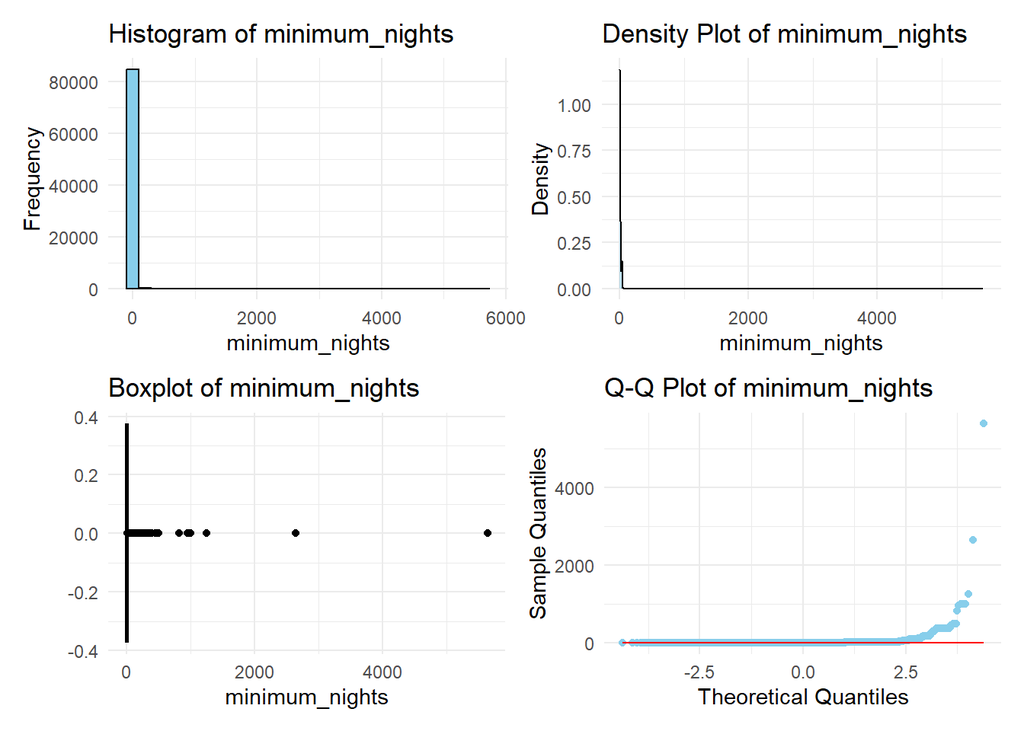

```r
# Plot summary info
plot_info(data_outlier_2, "minimum_nights")
```

```r
# Print total amount of > 370 minimum_nights
data_outlier_2 %>%
  dplyr::filter(minimum_nights > 370) %>%
  dplyr::summarise(count = n())
```

| count |
| --- |
| 15 |

```r
# Remove extreme values with upper threshold
data_outlier_TEMP2 <- data_outlier_2 %>%
  dplyr::filter(minimum_nights <= 95)
```

```r
# Print summary
summary(data_outlier_TEMP2$minimum_nights)
```

```
##    Min. 1st Qu.  Median    Mean 3rd Qu.    Max.
##   1.000   2.000   3.000   6.714   5.000  93.000
```

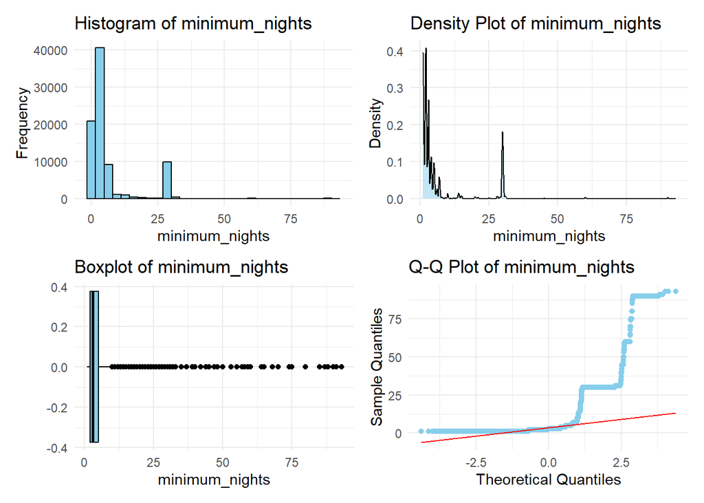

```r
# Plot summary info
plot_info(data_outlier_TEMP2, "minimum_nights")
```

```r
# Apply IQR outlier removal
data_iqr <- detect_outliers_iqr(data_outlier_TEMP2, "minimum_nights")
```

```
## --- minimum_nights ---
## Q1: 2 Q3: 5 IQR: 3
## Lower Bound: -2.5 Upper Bound: 9.5
## Number of outliers: 13661
```

```r
data_outlier_3 <- data_outlier_2
```

#### 4: number_of_reviews

Deze verdeling is vrij logisch. Ik zie geen reden tot outlier removal. Ook months_active laat geen verdachte verdeling zien.

```r
# Print summary
summary(data_outlier_3$number_of_reviews)
```

```
##    Min. 1st Qu.  Median    Mean 3rd Qu.    Max.
##    1.00    3.00   11.00   32.15   38.00 1024.00
```

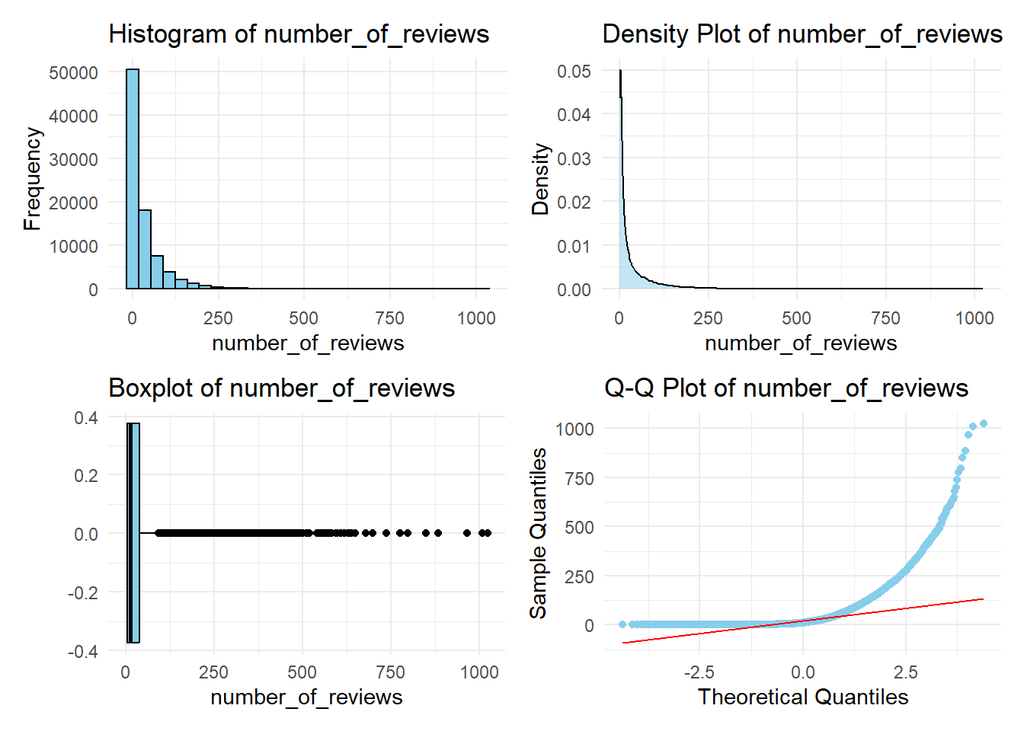

```r
# Plot summary info
plot_info(data_outlier_3, "number_of_reviews")
```

```r
# Print total amount of reviews > 100
data_outlier_3 %>%
  dplyr::filter(number_of_reviews > 100) %>%
  dplyr::summarise(count = n())
```

| count |
| --- |
| 7232 |

```r
# Create extra column that divides number of reviews by reviews per month
data_outlier_3 <- data_outlier_3 %>%
  dplyr::mutate(months_active = number_of_reviews / reviews_per_month)
```

```r
# Print summary
summary(data_outlier_3$months_active)
```

```
##    Min. 1st Qu.  Median    Mean 3rd Qu.    Max.
##    1.00   10.23   23.81   27.64   37.50  200.00
```

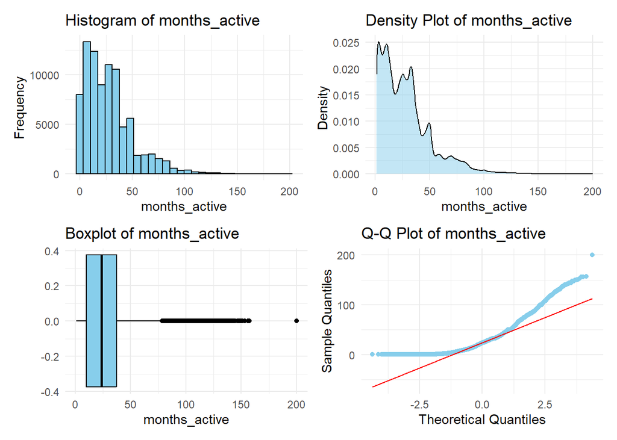

```r
# Plot summary info
plot_info(data_outlier_3, "months_active")
```

```r
data_outlier_4 <- data_outlier_3
```

#### 5: reviews_per_month

```r
# Print summary
summary(data_outlier_4$reviews_per_month)
```

```
##    Min. 1st Qu.  Median    Mean 3rd Qu.    Max.
##   0.010   0.220   0.740   1.376   2.010  90.000
```

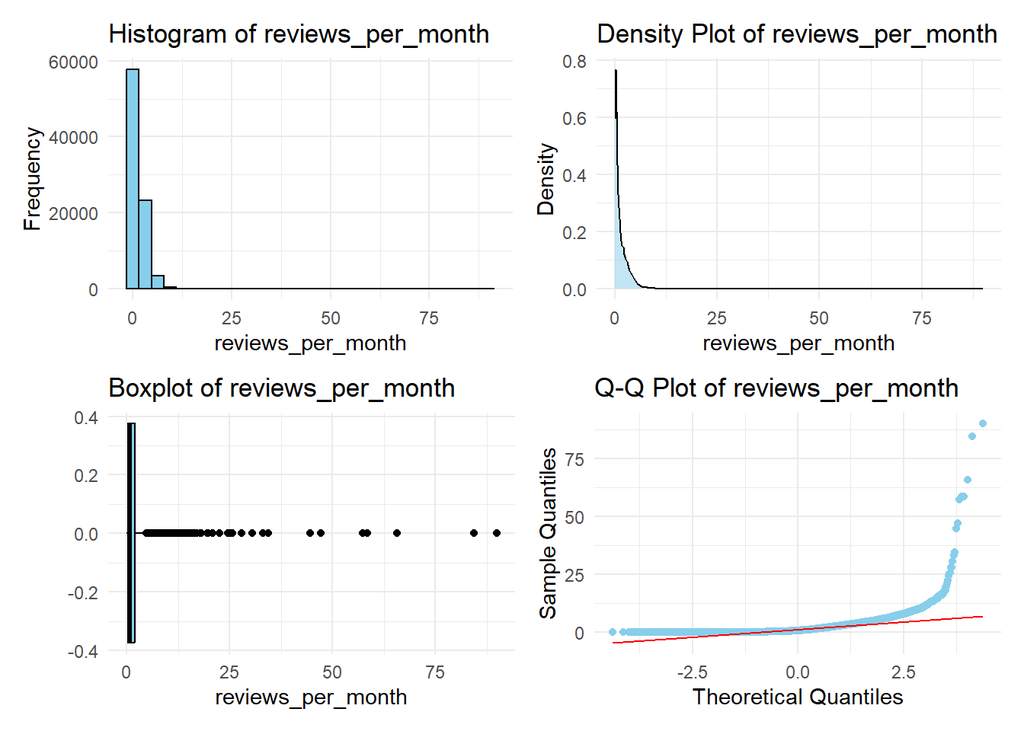

```r
# Plot summary info
plot_info(data_outlier_4, "reviews_per_month")
```

```r
# Create new column 'max_stays_per_month'
data_outlier_4 <- data_outlier_4 %>%
  dplyr::mutate(max_stays_per_month = 31 / minimum_nights)
```

```r
# Print summary
summary(data_outlier_4$max_stays_per_month)
```

```
##      Min.   1st Qu.    Median      Mean   3rd Qu.      Max.
##  0.005492  6.200000 10.333333 14.468374 15.500000 31.000000
```

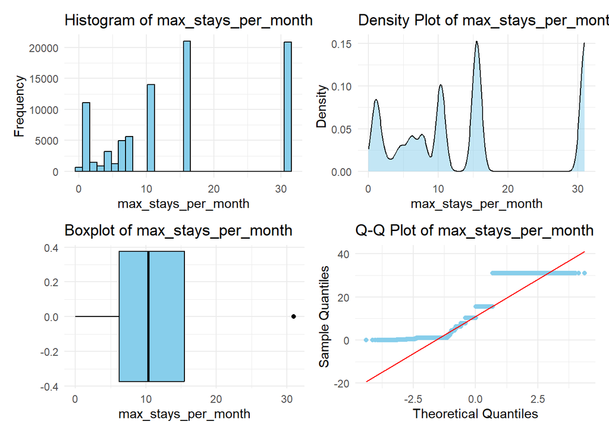

```r
# Plot summary info
plot_info(data_outlier_4, "max_stays_per_month")
```

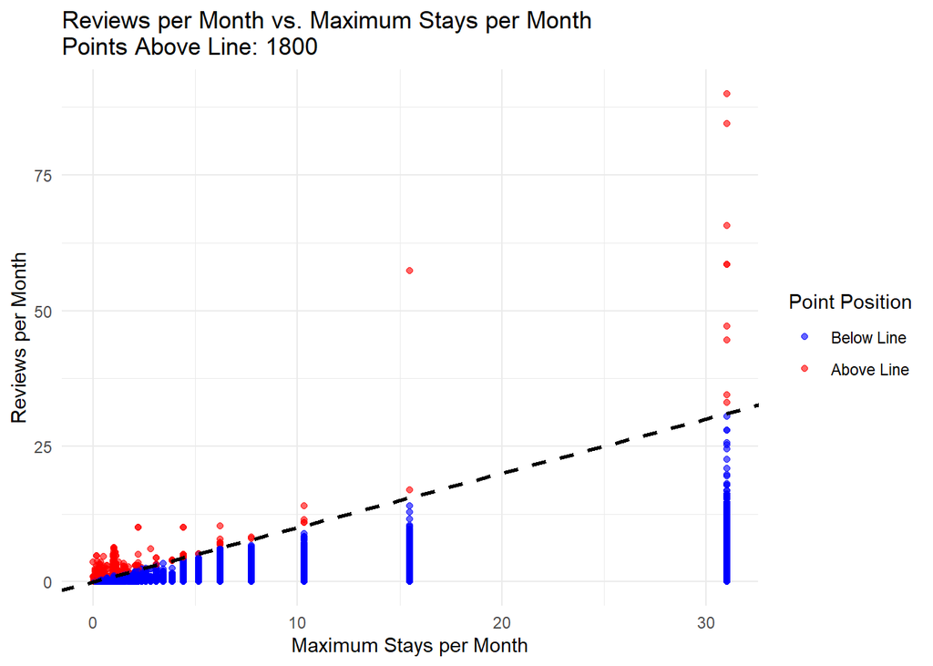

```r
# Count the points above the line y = x
count_above_line <- sum(data_outlier_4$reviews_per_month > data_outlier_4$max_stays_per_month, na.rm = TRUE)

# Scatterplot with y = x line, colored points, and count in title
ggplot(data_outlier_4, aes(x = max_stays_per_month, y = reviews_per_month)) +
  geom_point(aes(color = reviews_per_month > max_stays_per_month), alpha = 0.6) +  # Color points based on condition
  geom_abline(slope = 1, intercept = 0, color = "black", linetype = "dashed", size = 1) +  # y = x line
  scale_color_manual(values = c("FALSE" = "blue", "TRUE" = "red"), labels = c("Below Line", "Above Line")) +  # Define colors
  labs(
    title = paste("Reviews per Month vs. Maximum Stays per Month\nPoints Above Line:", count_above_line),
    x = "Maximum Stays per Month",
    y = "Reviews per Month",
    color = "Point Position"
  ) +
  theme_minimal()
```

```r
# Remove data_outlier_pos$reviews_per_month > data_outlier_pos$max_stays_per_month
data_outlier_5 <- data_outlier_4 %>%
  dplyr::filter(reviews_per_month <= max_stays_per_month)
```

#### 6: review_rate_number

Niets sus. Geen uitschieters.

```r
# Print summary
summary(data_outlier_5$review_rate_number)
```

```
##    Min. 1st Qu.  Median    Mean 3rd Qu.    Max.
##   1.000   2.000   3.000   3.278   4.000   5.000
```

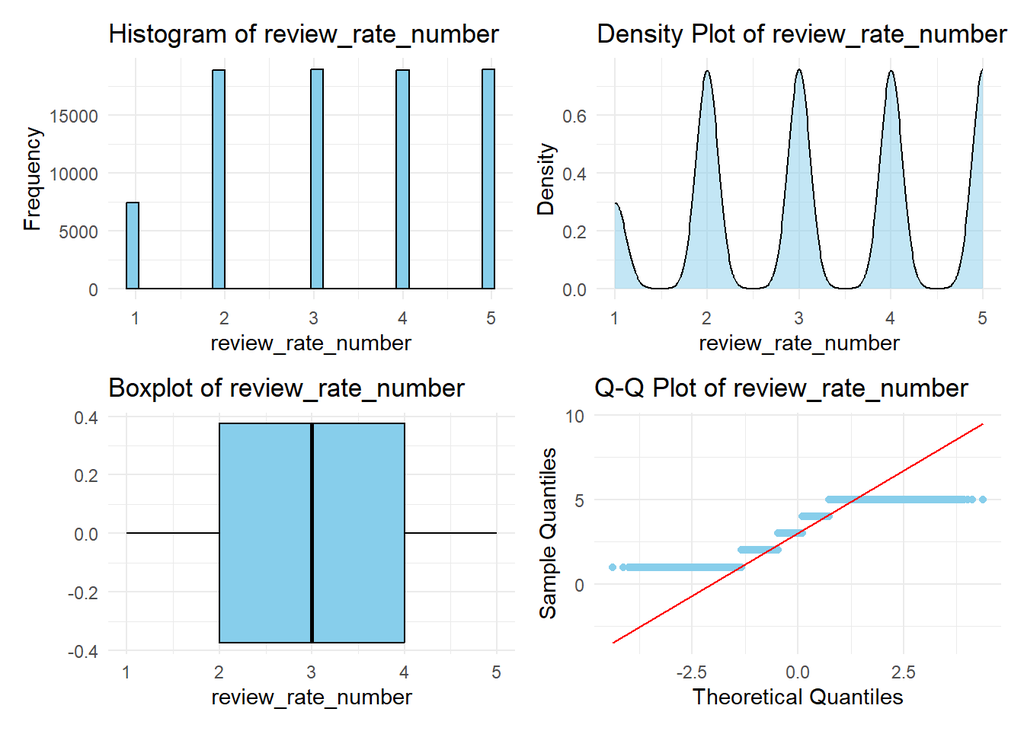

```r
# Plot summary info
plot_info(data_outlier_5, "review_rate_number")
```

```r
data_outlier_6 <- data_outlier_5
```

#### 7: availability_365

```r
# Print summary
summary(data_outlier_6$availability_365)
```

```
##    Min. 1st Qu.  Median    Mean 3rd Qu.    Max.
##     0.0     7.0   100.0   141.7   266.0  3677.0
```

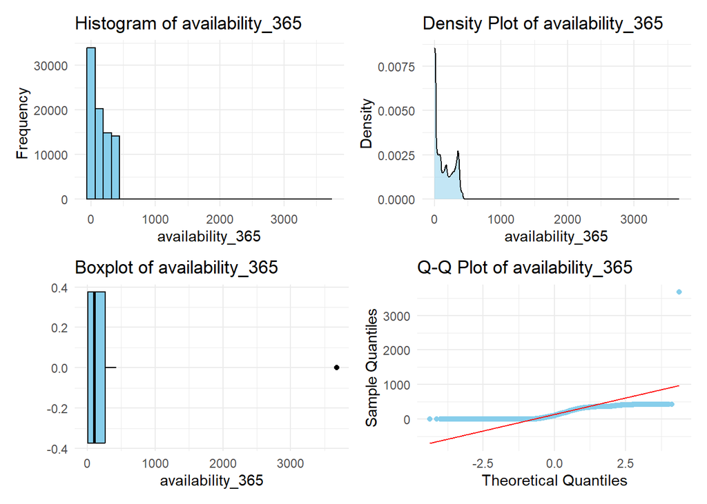

```r
# Plot summary info
plot_info(data_outlier_6, "availability_365")
```

```r
data_outlier_6 %>%
  dplyr::arrange(desc(availability_365)) %>%  # Sort rows by availability_365 in descending order
  dplyr::select(availability_365)            # Select only the availability_365 column
```

| availability_365 |
| --- |
| 3677 |
| 426 |
| 426 |
| 426 |
| 426 |
| 426 |
| 426 |
| 426 |
| 426 |
| 426 |

[output cut: 9990 more lines]

```r
# remove all values above 1000 in availability_365
data_outlier_7 <- data_outlier_6 %>%
  dplyr::filter(availability_365 <= 1000)
```

#### 8: price_usd

In principe geen uitschieters, maar wel opvallend dat de data niet normaal verdeeld is rond “normale” bedragen, alhoewel… verblijf is vaak duur.

```r
# Print summary
summary(data_outlier_7$price_usd)
```

```
##    Min. 1st Qu.  Median    Mean 3rd Qu.    Max.
##    50.0   340.0   625.0   626.1   914.0  1200.0
```

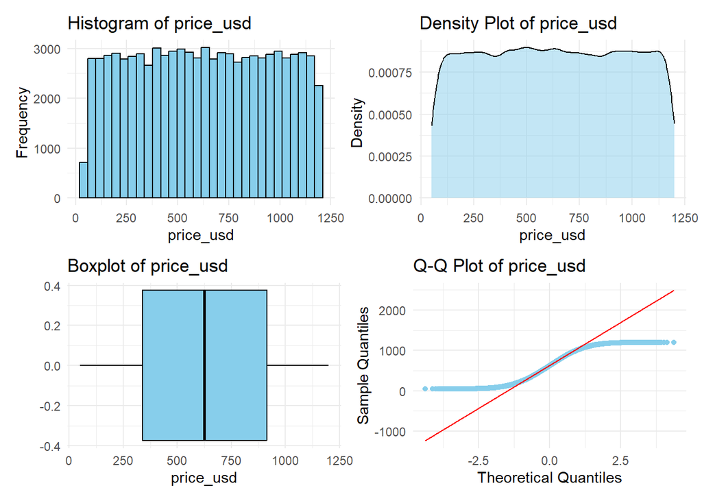

```r
# Plot summary info
plot_info(data_outlier_7, "price_usd")
```

```r
# Plot summary info
data_outlier_8 <- data_outlier_7
```

## Final inspection

```r
# Store last determined dataset in separate object
data_inspect <- data_outlier_8
```

```r
# Count missing data
data_inspect %>%
  dplyr::summarise(across(everything(), ~ sum(is.na(.)))) %>%
  tidyr::pivot_longer(
    cols = everything(),
    names_to = "variable",
    values_to = "na_count"
  )
```

| variable | na_count |
| --- | --- |
| cancellation_policy | 0 |
| room_type | 0 |
| construction_year | 0 |
| service_fee | 0 |
| minimum_nights | 0 |
| number_of_reviews | 0 |
| reviews_per_month | 0 |
| review_rate_number | 0 |
| availability_365 | 0 |
| price_usd | 0 |

[output cut: 2 more lines]

```r
# Inspect data structure
dplyr::glimpse(data_inspect)
```

```
## Rows: 83,096
## Columns: 12
## $ cancellation_policy <ord> strict, moderate, moderate, flexible, moderate, mo…
## $ room_type           <fct> Private room, Entire home/apt, Entire home/apt, En…
## $ construction_year   <int> 2020, 2007, 2009, 2013, 2015, 2009, 2005, 2015, 20…
## $ service_fee         <dbl> 193, 28, 41, 115, 14, 212, 204, 58, 64, 121, 143, …
## $ minimum_nights      <int> 10, 30, 10, 3, 45, 45, 2, 2, 1, 5, 2, 4, 2, 3, 2, …
## $ number_of_reviews   <int> 9, 45, 9, 74, 49, 49, 430, 118, 160, 53, 188, 167,…
## $ reviews_per_month   <dbl> 0.21, 0.38, 0.10, 0.59, 0.40, 0.40, 3.47, 0.99, 1.…
## $ review_rate_number  <int> 4, 4, 3, 3, 5, 5, 3, 5, 3, 4, 4, 4, 3, 3, 4, 3, 4,…
## $ availability_365    <int> 286, 228, 289, 374, 224, 219, 180, 375, 1, 163, 25…
## $ price_usd           <dbl> 966, 142, 204, 577, 71, 1060, 1018, 291, 319, 606,…
## $ months_active       <dbl> 42.85714, 118.42105, 90.00000, 125.42373, 122.5000…
## $ max_stays_per_month <dbl> 3.1000000, 1.0333333, 3.1000000, 10.3333333, 0.688…
```

```r
data_ready <- data_inspect
```

## Save 1000 size sample

```r
# Take a random sample of 1000 rows
Airbnb_Open_Data_sample <- data_ready %>%
  sample_n(1000)

# Save the sampled dataset to a CSV file
write.csv(Airbnb_Open_Data_sample, "Airbnb_Open_Data_1000.csv", row.names = FALSE)
```

# Linear Regression

## Prepare data for analysis

```r
# Standardize relevant numeric variables
data_standardized <- data_ready %>%
  mutate(
    service_fee = as.numeric(scale(service_fee)),
    minimum_nights = as.numeric(scale(minimum_nights)),
    number_of_reviews = as.numeric(scale(number_of_reviews)),
    reviews_per_month = as.numeric(scale(reviews_per_month)),
    review_rate_number = as.numeric(scale(review_rate_number)),
    availability_365 = as.numeric(scale(availability_365))
  )
```

```r
# Check mean and standard deviation for scaled variables
summary(data_standardized)
```

```
##  cancellation_policy           room_type     construction_year
##  flexible:27627      Entire home/apt:43721   Min.   :2003
##  moderate:27785      Hotel room     :  108   1st Qu.:2007
##  strict  :27684      Private room   :37590   Median :2012
##                      Shared room    : 1677   Mean   :2012
##                                              3rd Qu.:2017
##                                              Max.   :2022
##   service_fee       minimum_nights    number_of_reviews reviews_per_month
##  Min.   :-1.73713   Min.   :-0.4800   Min.   :-0.5980   Min.   :-0.8266
##  1st Qu.:-0.86276   1st Qu.:-0.4800   1st Qu.:-0.5581   1st Qu.:-0.6976
##  Median :-0.00347   Median :-0.3907   Median :-0.3985   Median :-0.3968
##  Mean   : 0.00000   Mean   : 0.0000   Mean   : 0.0000   Mean   : 0.0000
##  3rd Qu.: 0.87090   3rd Qu.:-0.1230   3rd Qu.: 0.1005   3rd Qu.: 0.3951
##  Max.   : 1.73019   Max.   :32.0093   Max.   :17.0244   Max.   :17.8969
##  review_rate_number availability_365    price_usd      months_active
##  Min.   :-1.7750    Min.   :-1.0626   Min.   :  50.0   Min.   :  1.00
##  1st Qu.:-0.9958    1st Qu.:-1.0101   1st Qu.: 340.0   1st Qu.: 10.08
##  Median :-0.2167    Median :-0.3124   Median : 625.0   Median : 23.53
##  Mean   : 0.0000    Mean   : 0.0000   Mean   : 626.1   Mean   : 27.24
##  3rd Qu.: 0.5624    3rd Qu.: 0.9327   3rd Qu.: 914.0   3rd Qu.: 36.88
##  Max.   : 1.3415    Max.   : 2.1329   Max.   :1200.0   Max.   :200.00
##  max_stays_per_month
##  Min.   : 0.08493
##  1st Qu.: 6.20000
##  Median :15.50000
##  Mean   :14.75585
##  3rd Qu.:31.00000
##  Max.   :31.00000
```

```r
summary(data_standardized$minimum_nights)
```

```
##    Min. 1st Qu.  Median    Mean 3rd Qu.    Max.
## -0.4800 -0.4800 -0.3907  0.0000 -0.1230 32.0093
```

```r
summary(data_standardized$availability_365)
```

```
##    Min. 1st Qu.  Median    Mean 3rd Qu.    Max.
## -1.0626 -1.0101 -0.3124  0.0000  0.9327  2.1329
```

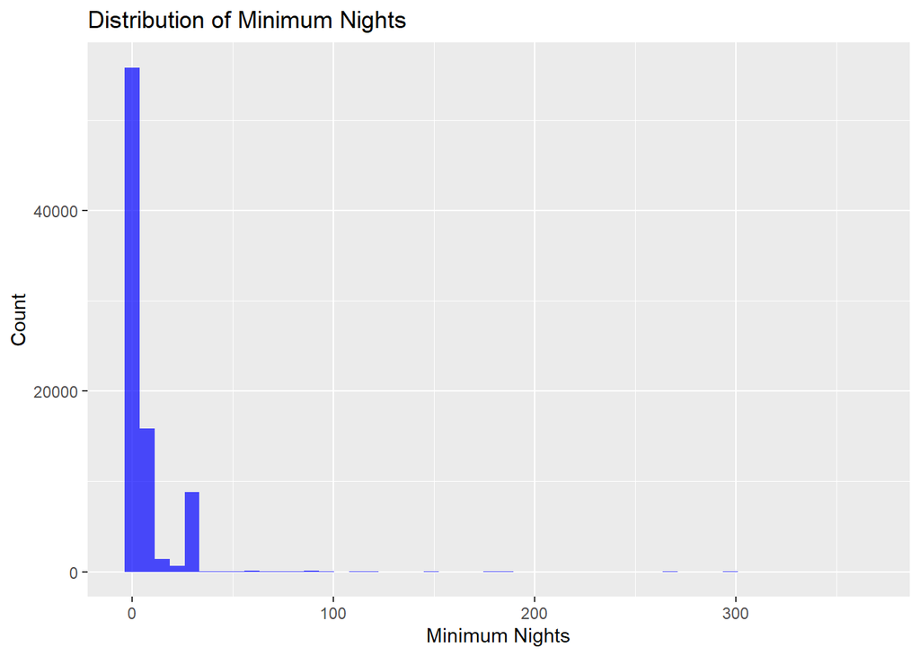

```r
library(ggplot2)

# Plot for minimum_nights
ggplot(data_ready, aes(x = minimum_nights)) +
  geom_histogram(bins = 50, fill = "blue", alpha = 0.7) +
  labs(title = "Distribution of Minimum Nights", x = "Minimum Nights", y = "Count")
```

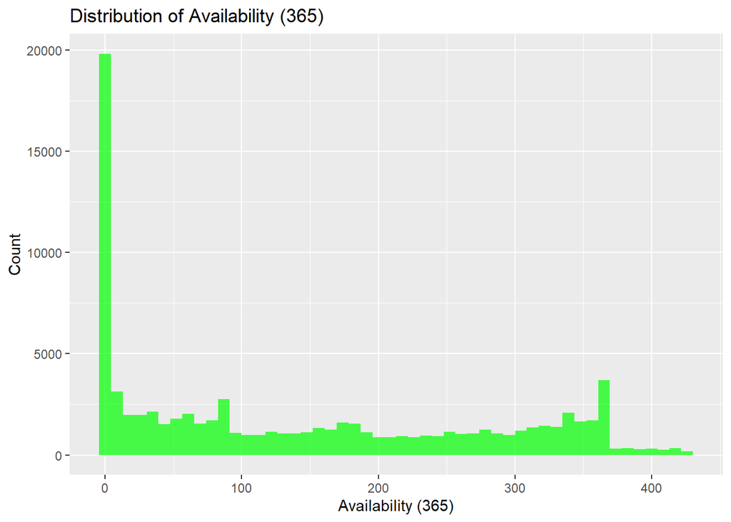

```r
# Plot for availability_365
ggplot(data_ready, aes(x = availability_365)) +
  geom_histogram(bins = 50, fill = "green", alpha = 0.7) +
  labs(title = "Distribution of Availability (365)", x = "Availability (365)", y = "Count")
```

```r
# Quantiles for extreme values
quantile(data_standardized$minimum_nights, probs = c(0.95, 0.99))
```

```
##      95%      99%
## 2.108449 2.108449
```

```r
quantile(data_standardized$availability_365, probs = c(0.95, 0.99))
```

```
##      95%      99%
## 1.667867 1.960414
```

```r
# Set active data to last processed set
data <- data_standardized
```

```r
library(dplyr)

data_ready %>%
  filter(minimum_nights > 100) %>%
  summarise(count = n())
```

| count |
| --- |
| 77 |

```r
dplyr::glimpse(data)
```

```
## Rows: 83,096
## Columns: 12
## $ cancellation_policy <ord> strict, moderate, moderate, flexible, moderate, mo…
## $ room_type           <fct> Private room, Entire home/apt, Entire home/apt, En…
## $ construction_year   <int> 2020, 2007, 2009, 2013, 2015, 2009, 2005, 2015, 20…
## $ service_fee         <dbl> 1.0216516, -1.4657758, -1.2697967, -0.1542232, -1.…
## $ minimum_nights      <dbl> 0.32332307, 2.10844866, 0.32332307, -0.30147088, 3…
## $ number_of_reviews   <dbl> -0.4383852, 0.2800850, -0.4383852, 0.8588526, 0.35…
## $ reviews_per_month   <dbl> -0.703775667, -0.599415515, -0.771302824, -0.47050…
## $ review_rate_number  <dbl> 0.5623744, 0.5623744, -0.2167364, -0.2167364, 1.34…
## $ availability_365    <dbl> 1.0827738, 0.6477045, 1.1052774, 1.7428790, 0.6176…
## $ price_usd           <dbl> 966, 142, 204, 577, 71, 1060, 1018, 291, 319, 606,…
## $ months_active       <dbl> 42.85714, 118.42105, 90.00000, 125.42373, 122.5000…
## $ max_stays_per_month <dbl> 3.1000000, 1.0333333, 3.1000000, 10.3333333, 0.688…
```

## Prepare functions

```r
test_multicol <- function(model) {
  # Ensure the model is valid
  if (!inherits(model, "lm")) {
    stop("Input must be a linear model (lm object).")
  }

  # Step 1: Show VIF results
  print(car::vif(model))

  # Step 2: Extract data from the model
  model_data <- model$model

  # Ensure only numeric columns are used for the correlation matrix
  numeric_data <- model_data %>%
    select_if(is.numeric)

  # Step 3: Show correlation matrix
  cor_matrix <- cor(numeric_data)

  # Step 4: Visualize correlation matrix
  print(ggcorrplot::ggcorrplot(cor_matrix,
                         method = "circle",
                         type = "lower",
                         lab = TRUE,
                         title = "Correlation Matrix of Numeric Predictors")
  )
}
```

## Models

### Model 1: price_usd (All)

```r
model_1 <- lm(price_usd ~
              cancellation_policy +
              room_type +
              construction_year +
              service_fee +
              minimum_nights +
              number_of_reviews +
              reviews_per_month +
              review_rate_number +
              availability_365,
            data = data_parsed)
summary(model_1)
```

```
##
## Call:
## lm(formula = price_usd ~ cancellation_policy + room_type + construction_year +
##     service_fee + minimum_nights + number_of_reviews + reviews_per_month +
##     review_rate_number + availability_365, data = data_parsed)
##
## Residuals:
##      Min       1Q   Median       3Q      Max
## -2.24096 -1.01424  0.00518  1.02484  2.12759
##
## Coefficients:
##                         Estimate Std. Error   t value Pr(>|t|)
## (Intercept)            1.341e+00  1.692e+00     0.792    0.428
## cancellation_policy.L  9.685e-03  8.404e-03     1.153    0.249
## cancellation_policy.Q  1.331e-02  8.382e-03     1.588    0.112
## room_typeHotel room   -5.861e-02  1.340e-01    -0.438    0.662
## room_typePrivate room  8.911e-03  9.846e-03     0.905    0.365
## room_typeShared room  -2.121e-03  3.504e-02    -0.061    0.952
## construction_year     -6.541e-04  8.409e-04    -0.778    0.437
## service_fee            5.000e+00  7.304e-05 68447.350   <2e-16 ***
## minimum_nights        -2.551e-04  1.748e-04    -1.459    0.145
## number_of_reviews      1.745e-04  1.170e-04     1.492    0.136
## reviews_per_month      1.254e-03  3.477e-03     0.361    0.718
## review_rate_number     2.052e-03  3.786e-03     0.542    0.588
## availability_365      -3.735e-05  3.648e-05    -1.024    0.306
## ---
## Signif. codes:  0 '***' 0.001 '**' 0.01 '*' 0.05 '.' 0.1 ' ' 1
##
## Residual standard error: 1.415 on 85230 degrees of freedom
## Multiple R-squared:      1,  Adjusted R-squared:      1
## F-statistic: 3.905e+08 on 12 and 85230 DF,  p-value: < 2.2e-16
```

```r
# Test multicollinearity
test_multicol(model_1)
```

```
##                         GVIF Df GVIF^(1/(2*Df))
## cancellation_policy 1.000140  2        1.000035
## room_type           1.007354  3        1.001222
## construction_year   1.000167  1        1.000083
## service_fee         1.000172  1        1.000086
## minimum_nights      1.014843  1        1.007394
## number_of_reviews   1.562410  1        1.249964
## reviews_per_month   1.566735  1        1.251693
## review_rate_number  1.004470  1        1.002232
## availability_365    1.016569  1        1.008251
```

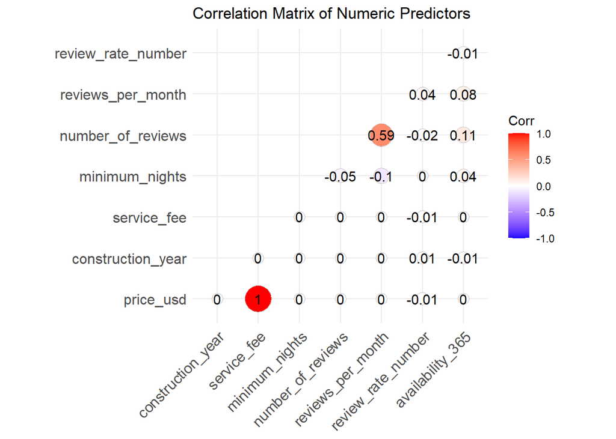

### Model 2: price_usd (Ex. service_fee, reviews_per_month)

```r
model_2 <- lm(price_usd ~
              cancellation_policy +
              room_type +
              construction_year +
              minimum_nights +
              number_of_reviews +
              review_rate_number +
              availability_365,
            data = data_parsed)
summary(model_2)
```

```
##
## Call:
## lm(formula = price_usd ~ cancellation_policy + room_type + construction_year +
##     minimum_nights + number_of_reviews + review_rate_number +
##     availability_365, data = data_parsed)
##
## Residuals:
##     Min      1Q  Median      3Q     Max
## -618.59 -285.92   -0.64  287.66  582.00
##
## Coefficients:
##                         Estimate Std. Error t value Pr(>|t|)
## (Intercept)            1.082e+03  3.968e+02   2.727  0.00639 **
## cancellation_policy.L -1.383e+00  1.970e+00  -0.702  0.48259
## cancellation_policy.Q  8.948e-01  1.965e+00   0.455  0.64889
## room_typeHotel room    4.030e+01  3.140e+01   1.283  0.19936
## room_typePrivate room  3.528e+00  2.308e+00   1.529  0.12633
## room_typeShared room   6.819e+00  8.214e+00   0.830  0.40640
## construction_year     -2.245e-01  1.972e-01  -1.138  0.25493
## minimum_nights        -5.013e-02  4.084e-02  -1.227  0.21969
## number_of_reviews      2.874e-02  2.212e-02   1.299  0.19378
## review_rate_number    -1.856e+00  8.859e-01  -2.095  0.03621 *
## availability_365      -2.726e-03  8.551e-03  -0.319  0.74987
## ---
## Signif. codes:  0 '***' 0.001 '**' 0.01 '*' 0.05 '.' 0.1 ' ' 1
##
## Residual standard error: 331.7 on 85232 degrees of freedom
## Multiple R-squared:  0.0001693,  Adjusted R-squared:  5.202e-05
## F-statistic: 1.443 on 10 and 85232 DF,  p-value: 0.1541
```

```r
# Test multicollinearity
test_multicol(model_2)
```

```
##                         GVIF Df GVIF^(1/(2*Df))
## cancellation_policy 1.000080  2        1.000020
## room_type           1.006251  3        1.001039
## construction_year   1.000135  1        1.000068
## minimum_nights      1.007739  1        1.003862
## number_of_reviews   1.016332  1        1.008133
## review_rate_number  1.000639  1        1.000319
## availability_365    1.016079  1        1.008007
```

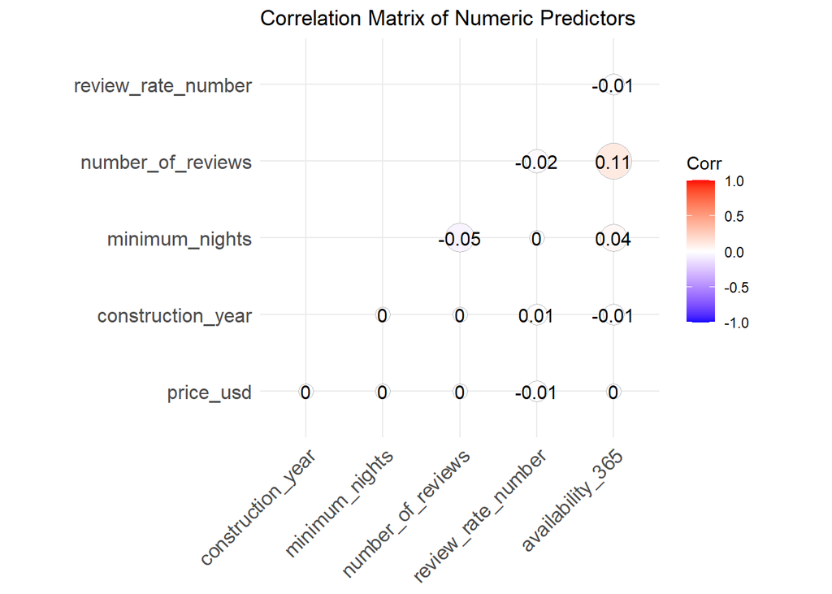

### Model 3: review_rate_number (Ex. service_fee, reviews_per_month)

```r
model_3 <- lm(review_rate_number ~
              cancellation_policy +
              room_type +
              construction_year +
              minimum_nights +
              number_of_reviews +
              price_usd +
              availability_365,
            data = data_parsed)
summary(model_3)
```

```
##
## Call:
## lm(formula = review_rate_number ~ cancellation_policy + room_type +
##     construction_year + minimum_nights + number_of_reviews +
##     price_usd + availability_365, data = data_parsed)
##
## Residuals:
##     Min      1Q  Median      3Q     Max
## -2.3454 -1.2685 -0.2592  0.7585  2.1673
##
## Coefficients:
##                         Estimate Std. Error t value Pr(>|t|)
## (Intercept)            7.709e-01  1.534e+00   0.503  0.61528
## cancellation_policy.L -1.185e-03  7.618e-03  -0.156  0.87640
## cancellation_policy.Q -2.687e-03  7.598e-03  -0.354  0.72358
## room_typeHotel room    3.051e-01  1.214e-01   2.513  0.01199 *
## room_typePrivate room  1.910e-02  8.921e-03   2.140  0.03232 *
## room_typeShared room   3.329e-02  3.176e-02   1.048  0.29450
## construction_year      1.264e-03  7.622e-04   1.659  0.09717 .
## minimum_nights         3.447e-05  1.579e-04   0.218  0.82722
## number_of_reviews     -4.690e-04  8.549e-05  -5.486 4.11e-08 ***
## price_usd             -2.774e-05  1.324e-05  -2.095  0.03621 *
## availability_365      -9.105e-05  3.306e-05  -2.754  0.00589 **
## ---
## Signif. codes:  0 '***' 0.001 '**' 0.01 '*' 0.05 '.' 0.1 ' ' 1
##
## Residual standard error: 1.282 on 85232 degrees of freedom
## Multiple R-squared:  0.0006896,  Adjusted R-squared:  0.0005723
## F-statistic: 5.882 on 10 and 85232 DF,  p-value: 6.115e-09
```

```r
# Test multicollinearity
test_multicol(model_3)
```

```
##                         GVIF Df GVIF^(1/(2*Df))
## cancellation_policy 1.000086  2        1.000021
## room_type           1.006170  3        1.001026
## construction_year   1.000118  1        1.000059
## minimum_nights      1.007756  1        1.003871
## number_of_reviews   1.015993  1        1.007965
## price_usd           1.000118  1        1.000059
## availability_365    1.015990  1        1.007963
```

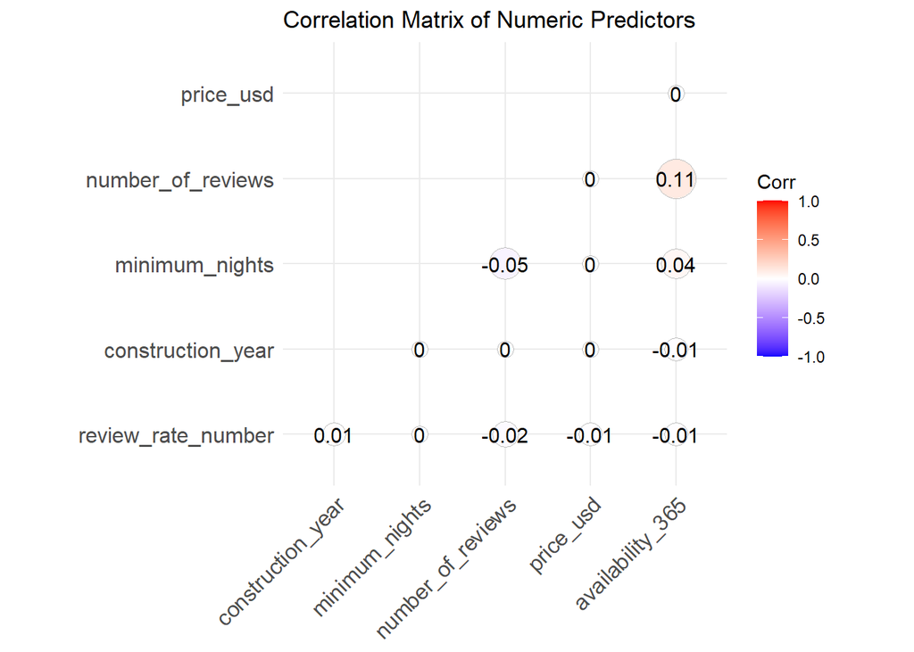